# Final Project

## Group Members

Ria Sharma, Haley Bondoc, Ethan Gabriele, Jiaming Zhang

## Introduction

The global airline industry, a pivotal component of modern travel, continuously seeks ways to elevate passenger satisfaction and operational efficiency. In an era where consumer preferences drive service modifications, airlines are increasingly scrutinizing the differing needs of their passengers. Our study specifically analyzes how family and couple travelers’ seating choices in the U.K., U.S., and Canada influence their satisfaction and the economic outcomes for airlines during the peak travel months of summer. We investigate whether enhancing accommodations in premium seating areas—such as providing child-friendly amenities and more comfortable seating—can significantly improve the travel experience for families and, concurrently, bolster airline profits. The analysis draws on patterns of seat class purchases by these traveler types to propose targeted service enhancements. Our thesis posits that family travelers are more likely to invest in premium seating compared to couples, yet often rate their experience less favorably, suggesting a critical gap in service provision that, if addressed, could reshape airline strategies to enhance both customer satisfaction and profitability.

## Background

### Data Overview

Our analysis utilizes the “Reviews and Ratings” dataset from Kaggle, which aggregates passenger feedback across global airlines. This dataset is pivotal for identifying trends in passenger satisfaction and tailoring services to enhance customer experience.

### Data Source and Attributes

- Directories
  - COURSE/project240/
  - COURSE/data/
- Files
  - COURSE/project240/projectfinalreport.Rmd
  - COURSE/project240/projectfinalreport.html
  - COURSE/data/airlines.csv
- Source: Kaggle - Airlines Reviews and Ratings by @ANANDSHAW2001
- Format: CSV
- Dimensions: 3291 rows × 15 columns
- Unit of Analysis: Each row corresponds to a review from an individual passenger.

### Column Details:

- Aircraft Type: Model of aircraft.
- User Reviews: Textual feedback on the flight.
- Country: Related to the airline or journey’s start/end.
- Type of Travelers: Category of the traveler (e.g., Solo Leisure, Family Leisure, Business, etc.)
- Route: Flight path from departure to arrival airport.
- Seat Types: Class of service (Economy, Business, First Class).
- Seat Comfort: Rating of seat comfort.
- Date Flown: Flight date.
- Cabin Staff Service: Rating of flight attendants’ service.
- Ground Service: Rating of check-in and boarding processes.
- Food & Beverages: Rating of onboard food and drinks.
- Wifi & Connectivity: Rating of WiFi and internet connectivity.
- Inflight Entertainment: Rating of entertainment options.
- Value For Money: Passenger’s value assessment.
- Recommended: Whether the passenger would recommend the airline.

### Factors Affecting Interpretation

#### Reviews Bias

Reviews typically represent polar opinions—extremely positive or negative—since these experiences are more likely to prompt feedback. This is important to keep in mind when analyzing data, as the opinions of the sample may not accurately represent the opinions of all passengers on all planes in the Northern Hemisphere.

#### Geographic and Seasonal Considerations

The data set also spans various airlines, flight classes, and geographic regions, capturing a wide array of passenger types and travel contexts. This breadth offers rich insights but also implies the need for careful interpretation, especially regarding the generalization of the findings. Because of this, we have limited the data to only include countries with the most reviews in the Northern Hemisphere (United Kingdom, United States, and Canada) so that sample sizes are large and seasonality is the same across the data. This is quite an American view of the world, however, it is what the data set has provided us with. This will not skew the data in any way, it will simply allow us to inspect seasonality and only focus on the three countries with the most data.

#### Passenger Type Focus

One more factor to consider is the type of passengers. In our introduction, we mentioned family and couple passengers, but left out two other passenger types in the data set: solo and business travelers. We did this for a variety of reasons. Firstly, business travelers are going to be using their employer’s money, rather than their own, so their opinions are not going to be derived from their own personal circumstances or “money’s worth” when the money isn’t their own. Furthermore, companies tend to allow their employees to fly in more expensive seating no matter the cost. So, airlines have minimal incentive to increase the odds that a business passenger purchases an expensive seat when those odds are already high and relatively fixed. As far as solo travelers, we figured that it would also be hard to give solo travelers an incentive to purchase a more expensive seat. People who are traveling alone and not for business are probably strictly trying to reach a destination and don’t have a reason to want to enjoy their flying experience more. The opposite can be said for family and couple travelers, though. Couples and parents of families are probably much more willing to spend more on their flight if they get better accommodations. This is assumed due to the idea that one, parents will enjoy their flight more if their children are more comfortable because they don’t have to deal with upset children, and two, couples will feel that their romantic getaway feels more genuine when their flight isn’t accompanied by crammed seats, screaming children, gross food, etc.

Below is a simple chart showing the percentage of purchased seats that are expensive by passenger type.

| Passenger Type | Percent Expensive |
| --- | --- |
| Business | 48.95288 |
| Couple Leisure | 43.46549 |
| Family Leisure | 27.58621 |
| Solo Leisure | 24.13793 |

### Data Focus of the Report

In this report, we scrutinize family and couple travelers’ tendencies to choose expensive seating options—namely Business or First Class. Our analysis seeks to understand how preferences for such seating arrangements could vary between these traveler demographics, particularly during peak travel periods. The insights derived could prove invaluable for airlines to customize and refine their service offerings, catering to the distinct needs of these traveler segments.

## Analysis

In this section, we delve into an analysis of passenger seat selection preferences and satisfaction ratings to identify trends and differences between family and couple travelers. Utilizing both numerical summaries and visual representations, we aim to clearly elucidate these trends and provide a basis for understanding their implications.

We begin with a table that summarizes the choice of seat type (expensive vs. cheap) by month for family and couple travelers. The table includes confidence intervals to measure the precision of the percentages calculated.

Table 1: Monthly Seat Selection Preferences Objective: This table aggregates the monthly distribution of seat choices between expensive and cheap options for both couple and family travelers. The data is further refined to include confidence intervals, providing a statistical measure of the precision of the calculated percentages.

| Passenger Type | Month | Total Expensive | Total Cheap | Total Flights | Percent Expensive | Lower CI | Upper CI |
| --- | --- | --- | --- | --- | --- | --- | --- |
| Couple Leisure | 4 | 22 | 33 | 55 | 40.000000 | 27.052904 | 52.94710 |
| Couple Leisure | 8 | 14 | 23 | 37 | 37.837838 | 22.210916 | 53.46476 |
| Couple Leisure | 12 | 21 | 22 | 43 | 48.837209 | 33.896666 | 63.77775 |
| Family Leisure | 4 | 5 | 19 | 24 | 20.833333 | 4.585591 | 37.08108 |
| Family Leisure | 8 | 9 | 24 | 33 | 27.272727 | 12.077610 | 42.46784 |
| Family Leisure | 12 | 1 | 21 | 22 | 4.545454 | -4.158642 | 13.24955 |

Figure 1: Expensive Seat Selection Over Time Description: This graph displays the percentage of purchased seats that were expensive over a 12-month period from 2016 to 2023, with red being used for passengers traveling as a couple and blue being used for passengers traveling as a family. The dots represent the percent of purchased seats that were expensive (which we define as business and first class), the shaded regions are the 95% confidence intervals of this per month, and the solid lines are smoothed trend lines. This visualization is particularly useful for identifying seasonal patterns, such as increased expensive seat selection during summer months.

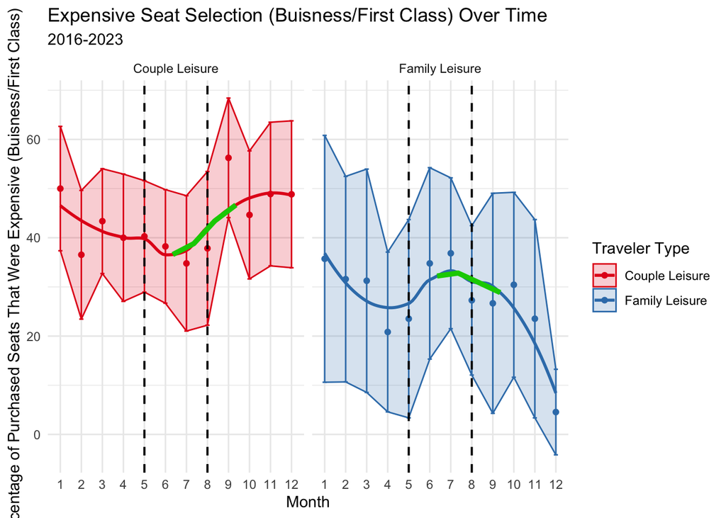

Statistical Inference We assess the statistical significance of the observed differences in seat selection preferences by calculating the difference in proportions of choosing expensive seats between couple and family travelers. This analysis is accompanied by confidence intervals to gauge the precision of our estimates. This calculation highlights a significant disparity, suggesting couple travelers are more inclined to select expensive seats than family travelers, particularly outside the peak travel months.Additional graphical analysis of ‘value’ ratings over time helps correlate the economic decisions with perceived satisfaction, offering deeper insights into how seat selection impacts traveler contentment.

Figure 2: This graph displays the value variable over a 12-month period from 2016-2023. The ‘value’ variable is a number 1-5 that rates the ratio of experience to cost, or ‘bang for your buck’. A rating of 5 is very good, and a rating of 1 is very bad. The graph shows that family and couple travelers rate the value of their flights fairly similarly. However, from around June to October, couples tend to rate their flights worse than family travelers, while the opposite is true for all other months of the year. This somewhat aligns with the previous graph, but the slight shift forward reveals something different.

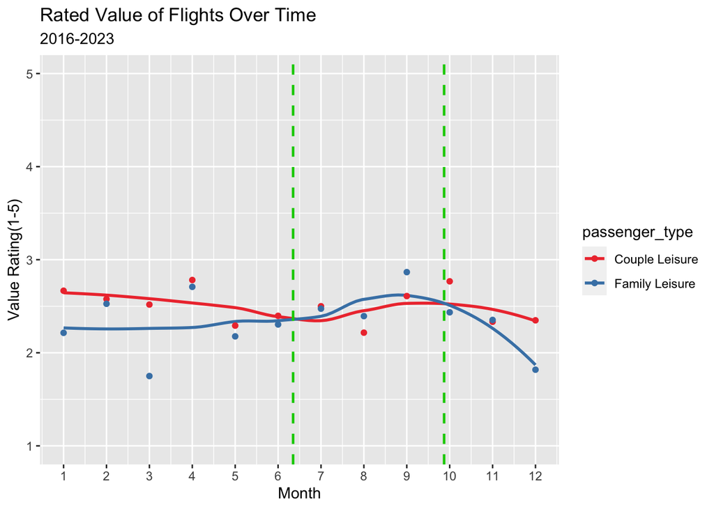

Analysis of Trends: As the percentage of couple travelers that purchase expensive seating climbs back up after the lowpoint in July, couple travelers simultaneously rate the value of their flight worse than family travelers. The opposite can be said for family travelers, where when the percentage of family travelers that purchase expensive seating falls down after the high point in July, family travelers simultaneously rate the value of their flight better than couple travelers.

```
##
##  Welch Two Sample t-test
##
## data:  unlist(y$`Couple Leisure`) and unlist(y$`Family Leisure`)
## t = 0.36287, df = 248.2, p-value = 0.717
## alternative hypothesis: true difference in means is not equal to 0
## 95 percent confidence interval:
##  -0.2412443  0.3502122
## sample estimates:
## mean of x mean of y
##  2.516605  2.462121
```

The t-test outputs a p-value of .717, which is greater than alpha=.05, meaning we fail to reject the null hypothesis that couple travelers gave their flights a higher value than family travelers only by chance.

## Discussion

Our original thesis, based originally on non-statistical inference alone, claimed three ‘sub-theses’.

1. Family travelers in the U.K., U.S., and Canada are more likely to purchase expensive seating compared to couple travelers.
2. Family travelers in the U.K, U.S., and Canada are much more likely to purchase expensive tickets in the summer months.
3. Family travelers rate the value of their flight worse than couple travelers, most likely due to the level of annoyances from traveling in larger groups.

### First Thesis: Preference for Expensive Seating by Passenger Type

As stated earlier, the data contrasts with the first part of our initial thesis by revealing a stronger preference for expensive seating among couples rather than families. We previously thought family travelers would buy expensive tickets more often than couple travelers because they want their family to have a good time, but the data has shown the opposite to be true. The data asserts that couple travelers purchase more expensive seating than family travelers almost year-round. This could have many reasons, but we assume a significant factor is that a couple traveler is thinking ‘I want this to a be a romantic experience’ while a family traveler is thinking ’How can I get my kids to Disney World for as cheap as possible.”

### Second Thesis: Effects of Seasonality on Family Travelers

However, our thesis also states that family travelers are more likely to buy expensive seats during the summer, which turned out to be true. The data tells us that from May to August, the percentage of purchased family seats that were expensive peaks, with the maximum occurring in July. The opposite is true for couple travelers (which we will dive into shortly), which gives us good evidence that the reason is related specifically to passenger type. It is our best assumption that the reason is that summer break in K-12 schools allows for families to take their children on vacation for more extended periods of time. Families are also much more willing to ‘go all out’ on expenditures, as summertime is viewed as the time to take your kids on vacation and create an experience as enjoyable as possible for the children and adults.

### Potential Shortcomings

Data Limitations: The dataset predominantly covers travelers from only three countries and may not capture global trends accurately. Moreover, it primarily includes travelers who opted to leave feedback, which could skew results toward more extreme experiences.

Seasonal Analysis Complexity: While we noted seasonal trends, the analysis could be refined by considering other factors like holiday periods, airline promotions, or economic conditions during the data collection period.

Satisfaction Measurement: The value ratings are subjective and based on individual expectations, which can vary widely among passengers. The scale used (1 to 5) might not capture nuanced differences in passenger satisfaction.

### Future Directions

Broader Geographic Scope: Expanding the dataset to include more countries could provide insights into cultural differences in travel preferences and satisfaction.

Longitudinal Analysis: Tracking the same types of travelers over several years would help in understanding how their preferences and behaviors evolve over time.

Qualitative Insights: Incorporating qualitative data from passenger interviews or focus groups could add depth to our understanding of why certain preferences exist and how they relate to overall satisfaction.

### Conclusions

By addressing these findings, airlines could enhance targeted marketing strategies and service adjustments to better meet the distinct needs of couples and families, potentially increasing both customer satisfaction and profitability.